# Imputation of Data with Non-linear Associations

## Preface

### R packages

In this practical, a number of R packages are used. If any of them are not installed you may be able to follow the practical but will not be able to run all of the code. The packages used (with versions that were used to generate the solutions) are:

- R version 3.6.0 (2019-04-26)
- `mice` (version: 3.4.0)
- `JointAI` (version: 0.5.1)
- `ggplot2` (version: 3.1.1)
- `reshape2` (version: 1.4.3)
- `ggpubr` (version: 0.2)

### Help files

You can find help files for any function by adding a `?` before the name of the function.

Alternatively, you can look up the help pages online at https://www.rdocumentation.org/ or find the whole manual for a package at https://cran.r-project.org/web/packages/available_packages_by_name.html

### Dataset

For this practical, we will use a subset of the **NHANES** dataset that we have seen in the previous practicals. It contains only those cases that have observed `wgt` and some columns that are not needed were excluded.

Download the file `NHANES_for_practicals_2.RData` from [here](https://nerler.github.io/EP16_Multiple_Imputation/practical/data/index.html). To load this dataset, you can use the command `file.choose()` which opens the explorer and allows you to navigate to the location of the file `NHANES_for_practicals_2.RData` on your computer. If you know the path to the file, you can also use `load("<path>/NHANES_for_practicals_2.RData")`.

### Aim

The focus of this practical is the imputation of data that has features that require special attention.

In the interest of time, we will focus on these features and **abbreviate steps that are the same as in any imputation setting** (e.g., getting to know the data or checking that imputed values are realistic). **Nevertheless, these steps are of course required when analysing data in practice.**

Our aim is to fit the following **linear regression model for weight**:

```r
mod <- lm(wgt ~ gender + bili + age * (chol + HDL) + hgt)
```

We expect that the effects of cholesterol and HDL may differ with age, and, hence, include **interaction terms** between `age` and `chol` and `HDL`, respectively.

Additionally, we want to include the other variables in the dataset as auxiliary variables.

## Imputation using **mice**

When the analysis model of interest involves interaction terms between incomplete variables, **mice** has limited options to reduce the bias that may be introduced by naive handling of the missing values.

Use of the “Just Another Variable” approach can in some settings reduce bias. Alternatively, we can use passive imputation, i.e., calculate the interaction terms in each iteration of the MICE algorithm. Furthermore, predictive mean matching tends to lead to less bias than normal imputation models.

### Just Another Variable approach

#### Task 1

- Calculate the interaction terms in the incomplete data.
- Perform the setup-run of `mice()` without any iterations.

#### Solution 1

```r
# calculate the interaction terms
NHANES$agechol <- NHANES$age * NHANES$chol
NHANES$ageHDL <- NHANES$age * NHANES$HDL

# setup run
imp0 <- mice(NHANES, maxit = 0,
             defaultMethod = c('norm', 'logreg', 'polyreg', 'polr'))
imp0
```

```
## Class: mids
## Number of multiple imputations:  5
## Imputation methods:
##      wgt   gender     bili      age     chol      HDL      hgt     educ     race      SBP   hypten
##       ""       ""   "norm"       ""   "norm"   "norm"   "norm"   "polr"       ""   "norm" "logreg"
##       WC  agechol   ageHDL
##   "norm"   "norm"   "norm"
## PredictorMatrix:
##        wgt gender bili age chol HDL hgt educ race SBP hypten WC agechol ageHDL
## wgt      0      1    1   1    1   1   1    1    1   1      1  1       1      1
## gender   1      0    1   1    1   1   1    1    1   1      1  1       1      1
## bili     1      1    0   1    1   1   1    1    1   1      1  1       1      1
## age      1      1    1   0    1   1   1    1    1   1      1  1       1      1
## chol     1      1    1   1    0   1   1    1    1   1      1  1       1      1
## HDL      1      1    1   1    1   0   1    1    1   1      1  1       1      1
```

#### Task 2

Apply the necessary change to the imputation method and predictor matrix.

Since the interaction terms are calculated from the orignal variables, these interaction terms should not be used to impute the original variables.

#### Solution 2

```r
meth <- imp0$method
pred <- imp0$predictorMatrix

# change imputation for "bili" to pmm (to prevent negative values)
meth["bili"] <- 'pmm'

# changes in predictor matrix to prevent original variables being imputer based
# on the interaction terms
pred["chol", "agechol"] <- 0
pred["HDL", "ageHDL"] <- 0

meth
```

```
##      wgt   gender     bili      age     chol      HDL      hgt     educ     race      SBP   hypten
##       ""       ""    "pmm"       ""   "norm"   "norm"   "norm"   "polr"       ""   "norm" "logreg"
##       WC  agechol   ageHDL
##   "norm"   "norm"   "norm"
```

```r
pred
```

```
##         wgt gender bili age chol HDL hgt educ race SBP hypten WC agechol ageHDL
## wgt       0      1    1   1    1   1   1    1    1   1      1  1       1      1
## gender    1      0    1   1    1   1   1    1    1   1      1  1       1      1
## bili      1      1    0   1    1   1   1    1    1   1      1  1       1      1
## age       1      1    1   0    1   1   1    1    1   1      1  1       1      1
## chol      1      1    1   1    0   1   1    1    1   1      1  1       0      1
## HDL       1      1    1   1    1   0   1    1    1   1      1  1       1      0
## hgt       1      1    1   1    1   1   0    1    1   1      1  1       1      1
## educ      1      1    1   1    1   1   1    0    1   1      1  1       1      1
## race      1      1    1   1    1   1   1    1    0   1      1  1       1      1
## SBP       1      1    1   1    1   1   1    1    1   0      1  1       1      1
## hypten    1      1    1   1    1   1   1    1    1   1      0  1       1      1
## WC        1      1    1   1    1   1   1    1    1   1      1  0       1      1
## agechol   1      1    1   1    1   1   1    1    1   1      1  1       0      1
## ageHDL    1      1    1   1    1   1   1    1    1   1      1  1       1      0
```

#### Task 3

Run the imputation using the **JAV approach** and check the traceplot.

#### Solution 3

```r
# run imputation with the JAV approach
impJAV <- mice(NHANES, method = meth, predictorMatrix = pred,
                maxit = 10, m = 5)

plot(impJAV, layout = c(4, 6))
```

[output not shown]

#### Task 4

We skip the more detailed evaluation of the imputed values. With the settings given in the solution the chains have converged and distributions of the imputed values match the distributions of the observed data closely enough.

- Analyse the imputed data and pool the results.

#### Solution 4

```r
miraJAV <- with(impJAV,
                lm(wgt  ~ gender + bili + age + chol + HDL + agechol + ageHDL + hgt))
summary(pool(miraJAV), conf.int = TRUE)
```

|  | estimate | std.error | statistic | df | p.value | 2.5 % | 97.5 % |
| --- | --- | --- | --- | --- | --- | --- | --- |
| (Intercept) | -107.7481326 | 19.90290458 | -5.413689 | 374.5751 | 1.021259e-07 | -146.88355981 | -68.61270533 |
| genderfemale | 3.9678385 | 1.90594622 | 2.081821 | 436.2734 | 3.794119e-02 | 0.22186051 | 7.71381652 |
| bili | -6.4059293 | 2.81669579 | -2.274271 | 389.7943 | 2.343453e-02 | -11.94374633 | -0.86811226 |
| age | 0.6819860 | 0.23036721 | 2.960430 | 433.2345 | 3.239613e-03 | 0.22920963 | 1.13476231 |
| chol | 9.9356522 | 2.09981307 | 4.731684 | 352.1432 | 3.012815e-06 | 5.80590057 | 14.06540388 |
| HDL | -21.2627528 | 6.16943415 | -3.446467 | 329.3462 | 6.230156e-04 | -33.39922074 | -9.12628479 |
| agechol | -0.1588015 | 0.04128701 | -3.846284 | 326.7207 | 1.378002e-04 | -0.24002346 | -0.07757962 |
| ageHDL | 0.1460312 | 0.12341871 | 1.183218 | 360.0984 | 2.373672e-01 | -0.09668077 | 0.38874319 |
| hgt | 98.0234331 | 9.21483490 | 10.637568 | 414.3559 | 0.000000e+00 | 79.90977990 | 116.13708620 |

### Passive Imputation

For the passive imputation, we can re-use the adjusted versions of `meth` and `pred` we created for the JAV approach, but additional changes to `meth` are necessary.

#### Task 1

Specify the new imputation method, i.e., adapt `meth` and save it as `methPAS`.

For passive imputation instead of an imputation method you need to specify the formula used to calculate the value that is imputed passively.

#### Solution 1

```r
# changes in imputation method for passive imputation
methPAS <- meth
methPAS[c("agechol", "ageHDL")] <- c("~I(age*chol)", "~I(age*HDL)")
```

#### Task 2

Run the imputation using **passive imputation** and check the traceplot.

#### Solution 2

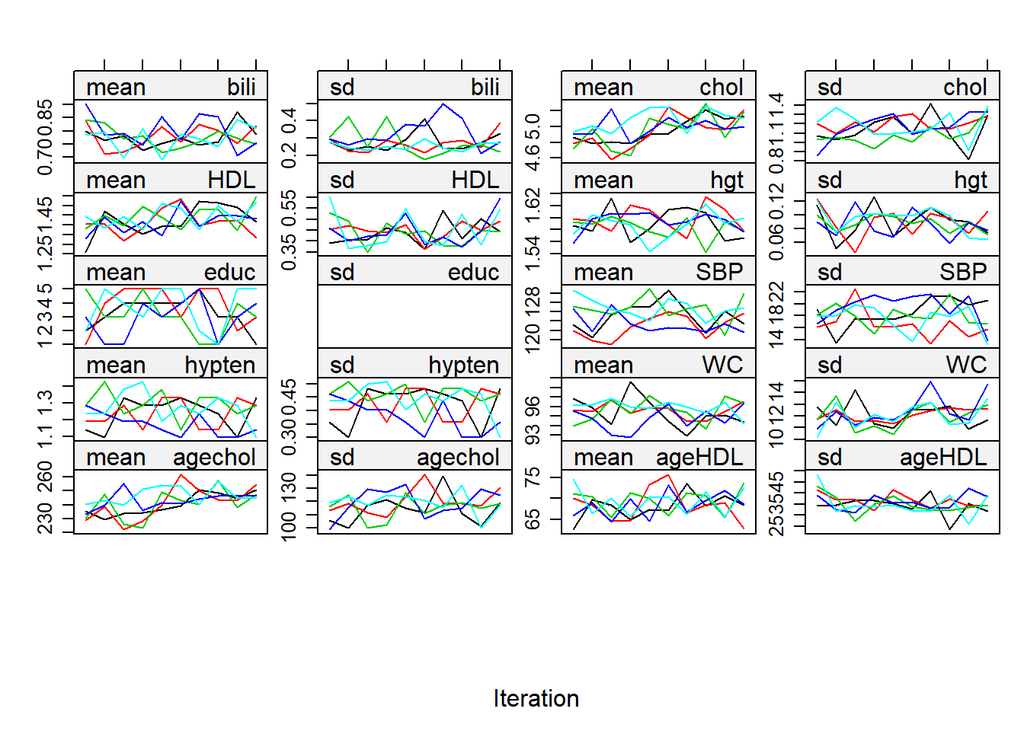

```r
# run imputation with passive imputation
impPAS <- mice(NHANES, method = methPAS, predictorMatrix = pred,
                maxit = 10, m = 5)
plot(impPAS, layout = c(4, 6))
```

#### Task 3

We will again skip the detailed evaluation of convergence and the imputed values.

- Analyse the imputed data and pool the results.

#### Solution 3

```r
miraPAS <- with(impPAS,
                lm(wgt ~ gender + bili + age + chol + HDL + agechol + ageHDL + hgt))

summary(pool(miraPAS), conf.int = TRUE)
```

|  | estimate | std.error | statistic | df | p.value | 2.5 % | 97.5 % |
| --- | --- | --- | --- | --- | --- | --- | --- |
| (Intercept) | -104.1058142 | 20.07775720 | -5.185132 | 237.0577 | 3.252054e-07 | -143.65942854 | -64.55219984 |
| genderfemale | 3.8043673 | 1.89833477 | 2.004055 | 455.7435 | 4.565544e-02 | 0.07379233 | 7.53494230 |
| bili | -7.5574045 | 2.77758127 | -2.720858 | 398.6730 | 6.760424e-03 | -13.01794100 | -2.09686809 |
| age | 0.5391666 | 0.22594312 | 2.386293 | 437.8306 | 1.742637e-02 | 0.09509864 | 0.98323448 |
| chol | 9.0248789 | 2.13434039 | 4.228416 | 317.1050 | 2.845220e-05 | 4.82562145 | 13.22413630 |
| HDL | -22.5056518 | 6.14517593 | -3.662328 | 236.9449 | 2.792615e-04 | -34.61181038 | -10.39949323 |
| agechol | -0.1374820 | 0.04189486 | -3.281595 | 331.3509 | 1.111501e-03 | -0.21989540 | -0.05506852 |
| ageHDL | 0.1728840 | 0.12246378 | 1.411715 | 289.3927 | 1.587162e-01 | -0.06814866 | 0.41391661 |
| hgt | 100.1004113 | 9.29535635 | 10.768862 | 306.1650 | 0.000000e+00 | 81.80954333 | 118.39127929 |

## Imputation with **JointAI**

**JointAI** provides functions that allow us to fit Bayesian regression models with incomplete covariates. The main functions are designed to resemble the standard functions to fit regression models with complete data.

For univariate outcomes the following functions are available:

- `lm_imp()`: for linear regression
- `glm_imp()`: for generalized linear regression (e.g., logistic, gamma or Poisson)
- `clm_imp()`: for ordinal (cumulative logit) regression

### Specification of the analysis model

Similar to the complete data versions, the functions from **JointAI** take the following arguments:

| `formula` | model formula |
| --- | --- |
| `data` | original, incomplete dataset |
| `family` | for glm’s: the distribution family of the outcome (e.g., `binomial()` for a logistic model) |

#### Task 1

- Specify the linear regression model with the model formula given at the beginning of this practical using `lm_imp()`.
- Find out the `class` of the resulting object.

You need to specify the arguments `formula`, `data` and `n.iter`. Set `n.iter = 100` (we will learn about this argument further down).

#### Solution 1

```r
lm1 <- lm_imp(wgt ~ gender + bili + age * (chol + HDL) + hgt, data = NHANES,
               n.iter = 100)

class(lm1)
```

```
## [1] "JointAI"
```

#### Task 2

The result is an object of class `JointAI`, which contains * the original data (`data`), * information on the type of model (`call`, `analysis_type`, `models`, `fixed`, `random`, `hyperpars`, `scale_pars`) and * information about the MCMC sampling (`mcmc_settings`), * the JAGS model (`model`) and * the MCMC sample (`MCMC`; if a sample was generated), * the computational time (`time`) of the MCMC sampling, and * some additional elements that are used by methods for objects of class `JointAI` but are typically not of interest for the user.

Check which imputation models were used in `lm1`.

The imputation model types are returned in the JointAI object under “models”.

#### Solution 2

```r
lm1$models
```

```
##    hgt   chol    HDL   bili
## "norm" "norm" "norm" "norm"
```

### Specification of the imputation models

In **JointAI**, there are some arguments related to the imputation part of the model:

| `models` | vector of imputation methods (for details see below and the vignette on [Model Specification](https://nerler.github.io/JointAI/articles/ModelSpecification.html#meth)) |
| --- | --- |
| `auxvars` | vector of names of variables that are not part of the analysis model but should be used to predict missing values (optional; for details see the vignette on [Model Specification](https://nerler.github… |
| `refcats` | allows specification of which category of categorical variables is used as reference (optional; for details see the vignette on [Model Specification](https://nerler.github.io/JointAI/articles/ModelSpe… |
| `trunc` | allow truncation of distributions of incomplete continuous covariates (for details see the vignette on [Model Specification](https://nerler.github.io/JointAI/articles/ModelSpecification.html#functions… |

Like in **mice** default imputation models are chosen based on the `class` of each of the incomplete variables. The default choices for baseline (not time-varying) covariates are

| name | model | variable type |
| --- | --- | --- |
| `norm` | linear regression | continuous variables |
| `logit` | logistic regression | factors with two levels |
| `multilogit` | multinomial logit model | unordered factors with >2 levels |
| `cumlogit` | cumulative logit model | ordered factors with >2 levels |

Alternative imputation methods are available for continuous baseline covariates:

| name | model | variable type |
| --- | --- | --- |
| `lognorm` | normal regression of the log-transformed variable | right-skewed variables >0 |
| `gamma` | Gamma regression (with log-link) | right-skewed variables >0 |
| `beta` | beta regression (with logit-link) | continuous variables with values in [0, 1] |

#### Task

Re-fit the linear regression model, but now

- specify a log-normal or a gamma distribution for `bili`
- set the reference category to the largest group
- use the other variables that are in the data as auxiliary variables

To specify a non-default imputation method use the argument `models = c(bili = ...)`.

To set the respective largest group as reference category for all categorical variables use the argument `refcats = "largest"`.

Auxiliary variables need to be specified explicitely using the argument `auxvars`. It takes a vector of variable names (each of them in quotes).

#### Solution

```r
lm2 <- lm_imp(wgt ~ gender + bili + age * (chol + HDL) + hgt, data = NHANES,
               auxvars = c('educ', 'race', 'SBP', 'hypten', 'WC'),
               models = c(bili = 'lognorm'), refcats = 'largest',
               n.iter = 100)
```

### Specification of the MCMC settings

Specification of the basic settings for the MCMC sampling can be achieved using the following arguments:

| `n.chains` | number of MCMC chains |
| --- | --- |
| `n.adapt` | number of iterations used in the adaptive phase |
| `n.iter` | number of iterations per MCMC chain in the sampling phase |

**JointAI** has more arguments than the ones given above, but in this practical we focus only on the most important. You may find out more about all the arguments in the vignette on [MCMC Settings](https://nerler.github.io/JointAI/articles/MCMCsettings.html).

By default, `n.chains = 3`, `n.adapt = 100` and `n.iter = 0`.

It is useful to use more than one chain to be able to evaluate convergence of the MCMC chains.

Samples in the adaptive phase are not used for the final MCMC sample. They are needed to optimize the MCMC sampler. When the number provided via the argument `n.adapt` is insufficient for this optimization a warning message will be printed. In simple models (e.g., linear regression) usually the default value of `n.adapt = 100` can be used.

The default value for `n.iter`, the number of iterations in the sampling phase is `0` (no MCMC sample will be created). The number of iterations that is needed depends on how complex the model and the data is and can range from somewhere as low as 100 up to several million.

In the following we will look at some criteria to determine if the number of MCMC samples that was used is sufficient.

### Evaluation of the MCMC sample

The first step after fitting a Bayesian model should be to confirm that the MCMC chains have converged. This can be done visually, using a traceplot (plotting the sampled values per parameter and chain across iterations) or using the Gelman-Rubin criterion.

#### Task 1

Investigate convergence of `lm2` by creating a traceplot using the function `traceplot()`. The plot should show a horizontal band without trends or patterns and the different chains should be mixed.

#### Solution 1

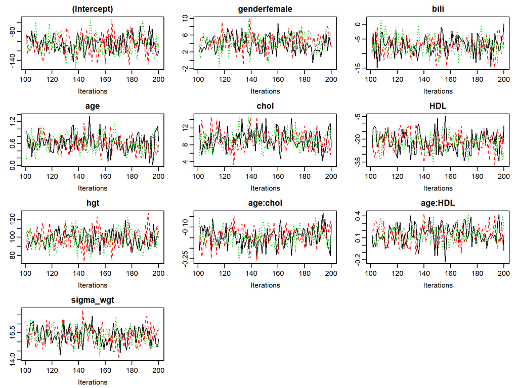

```r
traceplot(lm2)
```

#### Task 2

Investigate convergence of `lm2` using the Gelman-Rubin criterion, implemented in the function `GR_crit()`.

The upper limit of the confidence interval should not be much larger than 1.

#### Solution 2

```r
GR_crit(lm2)
```

```
## Potential scale reduction factors:
##
##              Point est. Upper C.I.
## (Intercept)       1.009      1.016
## genderfemale      1.012      1.056
## bili              0.997      0.999
## age               1.000      1.007
## chol              0.998      1.001
## HDL               1.000      1.000
## hgt               1.011      1.027
## age:chol          1.000      1.012
## age:HDL           1.001      1.004
## sigma_wgt         0.999      1.002
##
## Multivariate psrf
##
## 1.03
```

#### Continue

When we are satisfied with the convergence of the MCMC chains we can take a look at the MCMC sample is precise enough. We can do this by comparing the Monte Carlo error (which describes the error made since we have just a finite sample) to the estimated standard deviation. This is implemented in the function `MC_error()`.

#### Task 3

Calculate the Monte Carlo error for `lm2`.

#### Solution 3

```r
MC_error(lm2)
```

```
##                  est   MCSE     SD MCSE/SD
## (Intercept)  -105.02 1.2815 18.844   0.068
## genderfemale    4.27 0.1216  1.930   0.063
## bili           -7.15 0.1560  3.055   0.051
## age             0.61 0.0175  0.231   0.076
## chol            9.21 0.1763  2.114   0.083
## HDL           -21.79 0.3963  6.041   0.066
## hgt            99.07 0.6129  9.371   0.065
## age:chol       -0.14 0.0036  0.042   0.084
## age:HDL         0.14 0.0072  0.121   0.060
## sigma_wgt      15.36 0.0312  0.468   0.067
```

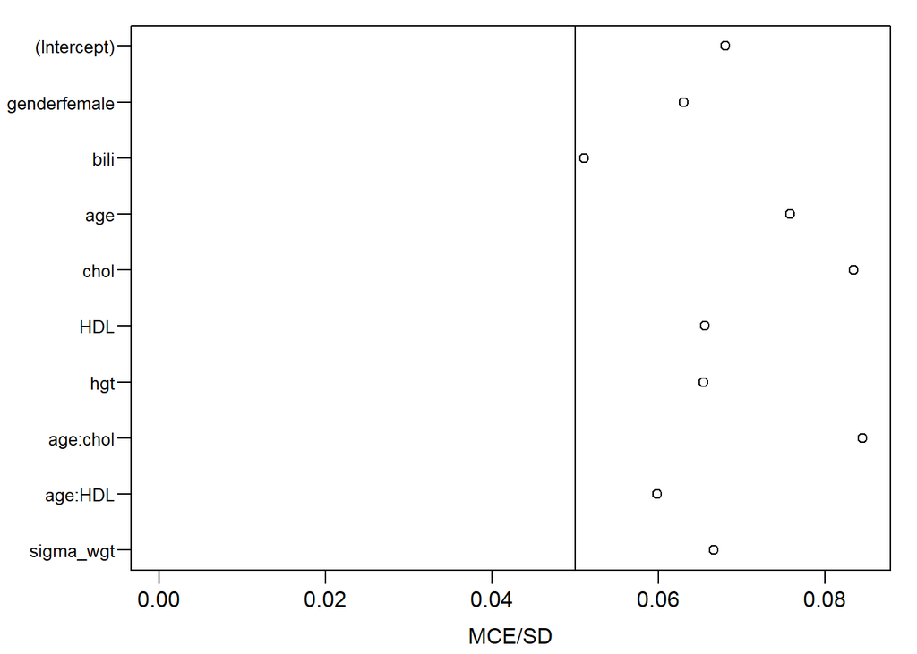

```r
par(mar = c(3.2, 5, 1, 1), mgp = c(2, 0.6, 0))
plot(MC_error(lm2))
```

### Results

#### Task

Get the summary of the model using the function `summary()`.

#### Solution

```r
summary(lm2)
```

```
##
##  Linear model fitted with JointAI
##
## Call:
## lm_imp(formula = wgt ~ gender + bili + age * (chol + HDL) + hgt,
##     data = NHANES, n.iter = 100, auxvars = c("educ", "race",
##         "SBP", "hypten", "WC"), refcats = "largest", models = c(bili = "lognorm"),
##     seed = 2019)
##
## Posterior summary:
##                  Mean      SD      2.5%    97.5% tail-prob. GR-crit
## (Intercept)  -105.021 18.8442 -141.7368 -70.2160     0.0000   1.016
## genderfemale    4.274  1.9299    0.5206   7.6209     0.0400   1.056
## bili           -7.149  3.0549  -13.1028  -1.2322     0.0133   0.999
## age             0.614  0.2306    0.1808   1.0830     0.0000   1.007
## chol            9.209  2.1136    5.5977  14.0853     0.0000   1.001
## HDL           -21.788  6.0406  -33.8030 -11.1291     0.0000   1.000
## hgt            99.073  9.3713   81.1938 116.7651     0.0000   1.027
## age:chol       -0.144  0.0422   -0.2342  -0.0691     0.0000   1.012
## age:HDL         0.144  0.1206   -0.0719   0.3879     0.2467   1.004
##
## Posterior summary of residual std. deviation:
##           Mean    SD 2.5% 97.5% GR-crit
## sigma_wgt 15.4 0.468 14.5  16.2       1
##
##
## MCMC settings:
## Iterations = 101:200
## Sample size per chain = 100
## Thinning interval = 1
## Number of chains = 3
##
## Number of observations: 500
```

## Additional exercise JointAI

### Monitoring imputed values

**JointAI** also allows us to extract imputed values to generate multiple imputed datasets that can, for instance, be used for a secondary analysis.

To be able to extract the imputed values, it is necessary to specify in advance that these values should be monitored (“recorded”). This can be done using the argument `monitor_params`.

`monitor_params` uses a number of key words to specify which (groups of) parameters or values should be monitored. Each key word works like a switch and can be set to `TRUE` or `FALSE`. For more details see the vignette on [Parameter Selection](https://nerler.github.io/JointAI/articles/SelectingParameters.html).

For monitoring imputed values, `monitor_params = c(imps = TRUE)` needs to be specified.

#### Task

Re-fit the linear regression model, but now additionally set the argument `monitor_params` to keep the imputed values.

#### Solution

```r
lm3 <- lm_imp(wgt ~ gender + bili + age * (chol + HDL) + hgt, data = NHANES,
               auxvars = c('educ', 'race', 'SBP', 'hypten', 'WC'),
               models = c(bili = 'lognorm'), refcats = 'largest',
               n.iter = 100, monitor_params = c(imps = TRUE))
```

### Extracting imputed data

The function `get_MIdat()` allows us to create multiple completed datasets from an object of class `JointAI`.

It takes the following arguments

| `object` | an object of class `JointAI` |
| --- | --- |
| `m` | number of imputed datasets |
| `include` | should the original, incomplete data be included? (default is `TRUE`) |
| `start` | first iteration of interest; allows discarding burn-in iterations |
| `minspace` | minimum number of iterations between iterations chosen as imputed values (default is 50) |
| `seed` | optional seed value |
| `export_to_SPSS` | logical; should the completed data be exported to SPSS? |
| `resdir` | optional directory for results (for export to SPSS) |
| `filename` | optional file name (for export to SPSS) |

#### Task 1

- Extract 5 imputed datasets from `lm3`.
- Inspect the resulting object.

#### Solution 1

```r
MIdat3 <- get_MIdat(lm3, m = 5)

head(MIdat3)
```

|  | Imputation_ | wgt | gender | bili | age | chol | HDL | hgt | educ | race | SBP | hypten | WC | agechol | ageHDL | .rownr | .id |
| --- | --- | --- | --- | --- | --- | --- | --- | --- | --- | --- | --- | --- | --- | --- | --- | --- | --- |
| 597 | 0 | 78.01789 | male | 1.1 | 67 | 6.13 | 1.09 | 1.7526 | College or above | other | 138.6667 | yes | 91.6 | 410.71 | 73.03 | 1 | 1 |
| 159 | 0 | 78.01789 | male | 0.7 | 39 | 4.65 | 1.14 | 1.7780 | High school graduate | Non-Hispanic White | 102.6667 | no | 84.5 | 181.35 | 44.46 | 2 | 2 |
| 2121 | 0 | 75.29633 | female | 0.5 | 64 | 4.14 | 1.29 | 1.6256 | College or above | other | NaN | yes | 91.6 | 264.96 | 82.56 | 3 | 3 |
| 2549 | 0 | 90.71847 | male | 0.8 | 36 | 3.47 | 1.37 | 1.9304 | some college | Non-Hispanic White | 115.3333 | yes | 95.4 | 124.92 | 49.32 | 4 | 4 |
| 1172 | 0 | 112.03732 | female | 0.6 | 33 | 6.31 | 1.27 | 1.7272 | some college | Non-Hispanic Black | 106.6667 | no | 119.6 | 208.23 | 41.91 | 5 | 5 |
| 1199 | 0 | 58.96701 | male | 0.7 | 62 | 4.47 | 0.85 | 1.6002 | High school graduate | other | 140.6667 | yes | 89.0 | 277.14 | 52.70 | 6 | 6 |

```r
summary(MIdat3)
```

```
##   Imputation_       wgt            gender          bili             age             chol
##  Min.   :0.0   Min.   : 39.01   male  :1512   Min.   :0.2000   Min.   :20.00   Min.   : 1.618
##  1st Qu.:1.0   1st Qu.: 65.20   female:1488   1st Qu.:0.6000   1st Qu.:31.00   1st Qu.: 4.270
##  Median :2.5   Median : 76.20                 Median :0.7000   Median :43.00   Median : 4.890
##  Mean   :2.5   Mean   : 78.25                 Mean   :0.7431   Mean   :45.02   Mean   : 5.005
##  3rd Qu.:4.0   3rd Qu.: 86.41                 3rd Qu.:0.9000   3rd Qu.:58.00   3rd Qu.: 5.640
##  Max.   :5.0   Max.   :167.38                 Max.   :2.9000   Max.   :79.00   Max.   :10.680
##                                               NA's   :47                       NA's   :41
##       HDL              hgt                          educ                     race
##  Min.   :0.1565   Min.   :1.378   Less than 9th grade :187   Mexican American  : 312
##  1st Qu.:1.1276   1st Qu.:1.626   9-11th grade        :414   Other Hispanic    : 348
##  Median :1.3400   Median :1.676   High school graduate:692   Non-Hispanic White:1092
##  Mean   :1.3968   Mean   :1.685   some college        :889   Non-Hispanic Black: 672
##  3rd Qu.:1.6000   3rd Qu.:1.753   College or above    :817   other             : 576
##  Max.   :3.1300   Max.   :1.930   NA's                :  1
##  NA's   :41       NA's   :11
##       SBP          hypten           WC            agechol           ageHDL           .rownr
##  Min.   : 79.16   no  :2207   Min.   : 57.77   Min.   : 45.54   Min.   :  7.92   Min.   :  1.0
##  1st Qu.:109.33   yes : 772   1st Qu.: 85.00   1st Qu.:140.16   1st Qu.: 39.37   1st Qu.:125.8
##  Median :118.67   NA's:  21   Median : 95.40   Median :222.31   Median : 57.40   Median :250.5
##  Mean   :120.32               Mean   : 96.30   Mean   :227.71   Mean   : 63.14   Mean   :250.5
##  3rd Qu.:128.92               3rd Qu.:105.10   3rd Qu.:296.40   3rd Qu.: 80.04   3rd Qu.:375.2
##  Max.   :202.00               Max.   :154.70   Max.   :725.90   Max.   :171.36   Max.   :500.0
##  NA's   :29                   NA's   :23       NA's   :246      NA's   :246
##       .id
##  Min.   :  1.0
##  1st Qu.:125.8
##  Median :250.5
##  Mean   :250.5
##  3rd Qu.:375.2
##  Max.   :500.0
##
```

We see that some columns were added to the data:

- `Imputation_` identifies the imputation number
- `.id` is the subject ID
- `.rownr` refers to the row number of the original data

#### Task 2

Similar to the functions `densplot()` from the **mice** package and `propplot()`, the function `plot_imp_distr()` from **JointAI** allows us to plot the distribution of the observed and imputed values for the incomplete variables.

It takes the following arguments

| `data` | a data.frame in long format containing multiple imputations (and the original incomplete data) |
| --- | --- |
| `imp` | the name of the variable specifying the imputation indicator |
| `id` | the name of the variable specifying the subject indicator |
| `rownr` | the name of a variable identifying which rows correspond to the same observation in the original (unimputed) data |
| `ncol`, `nrow` | optional number of rows and columns in the plot layout; automatically chosen if unspecified |

Check the imputed values in `MIdat3` using `plot_imp_distr()`.

#### Solution 2

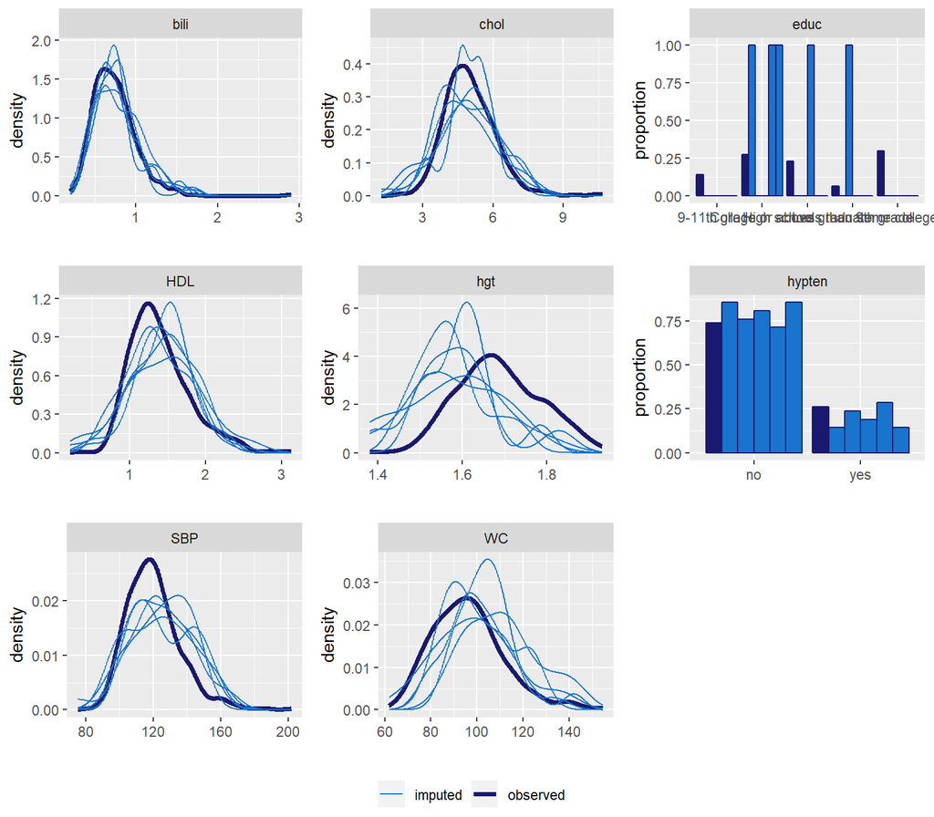

```r
plot_imp_distr(MIdat3)
```

### Transforming imputed data to a mids object

To perform standard analyses on the imputed data it is usefull to convert them to a `mids` object, so that they can be treated as if they had been imputed with `mice()`.

The **mice** package proves the function `as.mids()` to convert a long-format dataset (with original and multiple imputed datasets stacked onto each other) to a `mids` object.

#### Task

Transform `MIdat3` to a `mids` object and confirm that it has worked by checking the `class` of the result.

#### Solution

```r
mids3 <- as.mids(MIdat3, .imp = "Imputation_", .id = '.id')

class(mids3)
```

[output not shown]

© Nicole Erler